# Chemical variation of the human microbiome (2023)

This vignette runs the code to make the plots from the following paper:

> Dick JM. 2023. Two dimensions of chemical variation of the human microbiome across body sites and in COVID-19 patients. Manuscript in preparation.

This vignette was compiled on 2023-02-13 with **JMDplots** 1.2.17, **chem16S** 0.1.3, and **canprot** 1.1.2-5.

```r
library(JMDplots)
```

## Chemical metrics of reference proteomes as a function of oxygen tolerance and comparison with metaproteomes (Figure 1)

```r
sars16S_1()
```

```
## [1] "A. 86.8% of genus names in 'List of Prokaryotes ...' matched to GTDB"
```

[figure not shown]

**Data sources:** **(A)** *List of Prokaryotes according to their Aerotolerant or Obligate Anaerobic Metabolism* (Million and Raoult, 2018); **(B)** Gut Starch Diet (Maier et al., 2017), Ulcerative Colitis Gut (Thuy-Boun et al., 2022), Manus Basin Inactive Chimney (Meier et al., 2019), Manus Basin Active Chimneys (Reeves et al., 2014; Pjevac et al., 2018), Soda Lake Biomats (Kleiner et al., 2017), Mock Communities (Kleiner et al., 2017), Saanich Inlet (Hawley et al., 2017).

## Chemical variation of microbial proteins across body sites, after viral inactivation treatment, and multi-omics comparison (Figure 2)

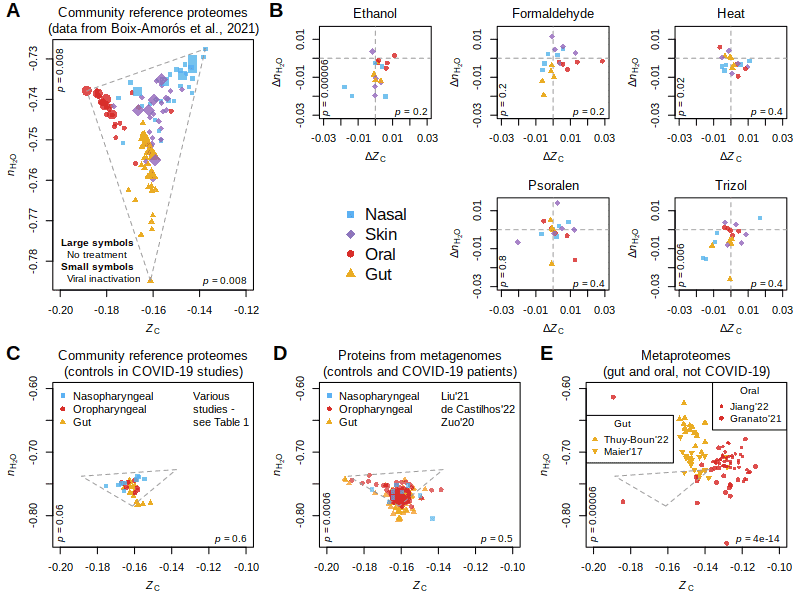

```r
sars16S_2()
```

**Data sources:** **(A)** Boix-Amorós et al. (2021); **(B)** Boix-Amorós et al. (2021); **(C)** See Table 1 in manuscript; **(D)** Liu et al. (2021), de Castilhos et al. (2022), Zuo et al. (2020); **(E)** Thuy-Boun et al. (2022), Maier et al. (2017), Jiang et al. (2022), Granato et al. (2021).

## Differences of chemical metrics of nasopharyngeal, oropharyngeal, and gut microbiomes between controls and COVID-19 patients (Figure 3)

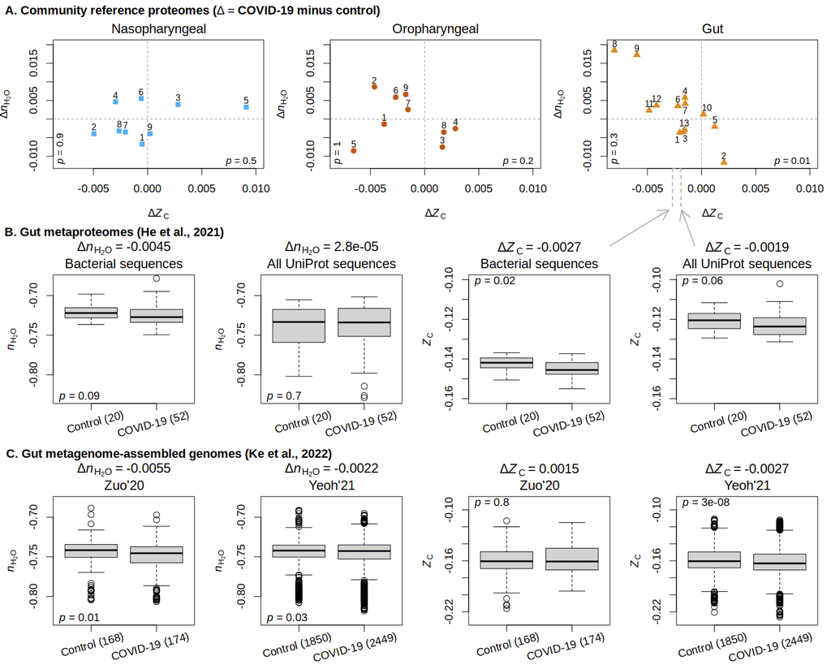

```r
sars16S_3()
```

**Data sources:** **(A)** See Table 1 in manuscript; **(B)** He et al. (2021); **(C)** MAGs (Ke et al., 2022), based on data from Zuo et al. (2020) and Yeoh et al. (2021).

## Overview of chemical variation of the human microbiome inferred from multi-omics datasets (Figure 4)

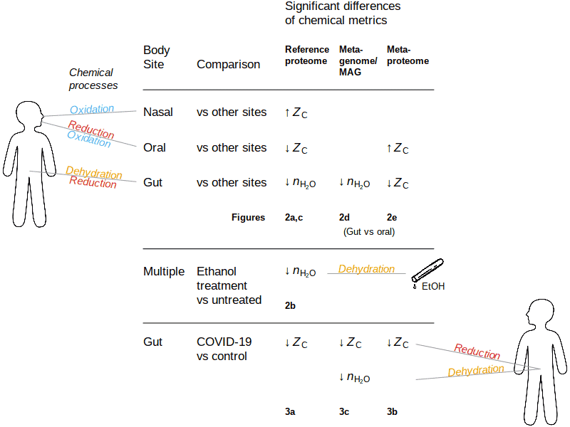

```r
sars16S_4()
```

## References

Boix-Amorós A, Piras E, Bu K, Wallach D, Stapylton M, Fernández-Sesma A, Malaspina D, Clemente JC. 2021. Viral inactivation impacts microbiome estimates in a tissue-specific manner. *mSystems* **6**(5): e00674–21. doi: 10.1128/mSystems.00674-21

de Castilhos J, Zamir E, Hippchen T, Rohrbach R, Schmidt S, Hengler S, Schumacher H, Neubauer M, Kunz S, Müller-Esch T, et al. 2022. Severe dysbiosis and specific *Haemophilus* and *Neisseria* signatures as hallmarks of the oropharyngeal microbiome in critically ill coronavirus disease 2019 (COVID-19) patients. *Clinical Infectious Diseases* **75**(1): e1063–e1071. doi: 10.1093/cid/ciab902

Granato DC, Neves LX, Trino LD, Carnielli CM, Lopes AFB, Yokoo S, Pauletti BA, Domingues RR, Sá JO, Persinoti G, et al. 2021. Meta-omics analysis indicates the saliva microbiome and its proteins associated with the prognosis of oral cancer patients. *Biochimica et Biophysica Acta (BBA) - Proteins and Proteomics* **1869**(8): 140659. doi: 10.1016/j.bbapap.2021.140659

Hawley AK, Torres-Beltrán M, Zaikova E, Walsh DA, Mueller A, Scofield M, Kheirandish S, Payne C, Pakhomova L, Bhatia M, et al. 2017. A compendium of multi-omic sequence information from the Saanich Inlet water column. *Scientific Data* **4**(1): 170160. doi: 10.1038/sdata.2017.160

He F, Zhang T, Xue K, Fang Z, Jiang G, Huang S, Li K, Gu Z, Shi H, Zhang Z, et al. 2021. Fecal multi-omics analysis reveals diverse molecular alterations of gut ecosystem in COVID-19 patients. *Analytica Chimica Acta* **1180**: 338881. doi: 10.1016/j.aca.2021.338881

Jiang X, Zhang Y, Wang H, Wang Z, Hu S, Cao C, Xiao H. 2022. In-depth metaproteomics analysis of oral microbiome for lung cancer. *Research* **2022**: 9781578. doi: 10.34133/2022/9781578

Ke S, Weiss ST, Liu Y-Y. 2022. Dissecting the role of the human microbiome in COVID-19 via metagenome-assembled genomes. *Nature Communications* **13**(1): 5235. doi: 10.1038/s41467-022-32991-w

Kleiner M, Thorson E, Sharp CE, Dong X, Liu D, Li C, Strous M. 2017. Assessing species biomass contributions in microbial communities via metaproteomics. *Nature Communications* **8**(1): 1558. doi: 10.1038/s41467-017-01544-x

Liu J, Liu S, Zhang Z, Lee X, Wu W, Huang Z, Lei Z, Xu W, Chen D, Wu X, et al. 2021. Association between the nasopharyngeal microbiome and metabolome in patients with COVID-19. *Synthetic and Systems Biotechnology* **6**(3): 135–143. doi: 10.1016/j.synbio.2021.06.002

Maier TV, Lucio M, Lee LH, VerBerkmoes NC, Brislawn CJ, Bernhardt J, Lamendella R, McDermott JE, Bergeron N, Heinzmann SS, et al. 2017. Impact of dietary resistant starch on the human gut microbiome, metaproteome, and metabolome. *mBio* **8**(5): e01343–17. doi: 10.1128/mBio.01343-17

Meier DV, Pjevac P, Bach W, Markert S, Schweder T, Jamieson J, Petersen S, Amann R, Meyerdierks A. 2019. Microbial metal-sulfide oxidation in inactive hydrothermal vent chimneys suggested by metagenomic and metaproteomic analyses. *Environmental Microbiology* **21**(2): 682–701. doi: 10.1111/1462-2920.14514

Million M, Raoult D. 2018. Linking gut redox to human microbiome. *Human Microbiome Journal* **10**: 27–32. doi: 10.1016/j.humic.2018.07.002

Pjevac P, Meier DV, Markert S, Hentschker C, Schweder T, Becher D, Gruber-Vodicka HR, Richter M, Bach W, Amann R, et al. 2018. Metaproteogenomic profiling of microbial communities colonizing actively venting hydrothermal chimneys. *Frontiers in Microbiology* **9**: 680. doi: 10.3389/fmicb.2018.00680

Reeves EP, Yoshinaga MY, Pjevac P, Goldenstein NI, Peplies J, Meyerdierks A, Amann R, Bach W, Hinrichs K-U. 2014. Microbial lipids reveal carbon assimilation patterns on hydrothermal sulfide chimneys. *Environmental Microbiology* **16**(11): 3515–3532. doi: 10.1111/1462-2920.12525

Thuy-Boun PS, Wang AY, Crissien-Martinez A, Xu JH, Chatterjee S, Stupp GS, Su AI, Coyle WJ, Wolan DW. 2022. Quantitative metaproteomics and activity-based protein profiling of patient fecal microbiome identifies host and microbial serine-type endopeptidase activity associated with ulcerative colitis. *Molecular & Cellular Proteomics* **21**(3): 100197. doi: 10.1016/j.mcpro.2022.100197

Yeoh YK, Zuo T, Lui GC-Y, Zhang F, Liu Q, Li AYL, Chung ACK, Cheung CP, Tso EYK, Fung KSC, et al. 2021. Gut microbiota composition reflects disease severity and dysfunctional immune responses in patients with COVID-19. *Gut* **70**(4): 698–706. doi: 10.1136/gutjnl-2020-323020

Zuo T, Zhang F, Lui GCY, Yeoh YK, Li AYL, Zhan H, Wan Y, Chung ACK, Cheung CP, Chen N, et al. 2020. Alterations in gut microbiota of patients with COVID-19 during time of hospitalization. *Gastroenterology* **159**(3): 944–955. doi: 10.1053/j.gastro.2020.05.048